# Normal (Gaussian) Distribution

## Expected Value and Variance

The theoretical expected value and variance for any distribution are generally found as follows. We cannot integrate \(f(x)\), but it can be demonstrated that expected value and variance simplify to the parameters \(\mu\) and \(\sigma^2\) for the normal distribution.

\[E[X] = \int\limits_{-\infty}^{+\infty} x f(x) \rightarrow \mu\]

\[Var[X] = \int\limits_{-\infty}^{+\infty} (x - \mu)^2 f(x) \rightarrow \sigma^2\]

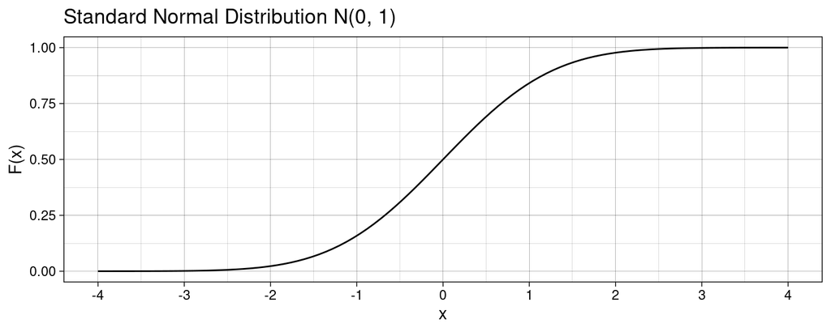

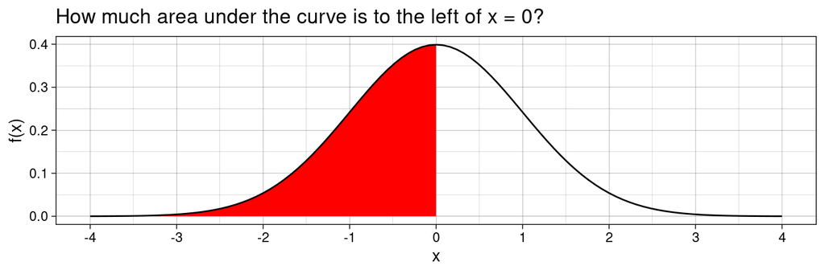

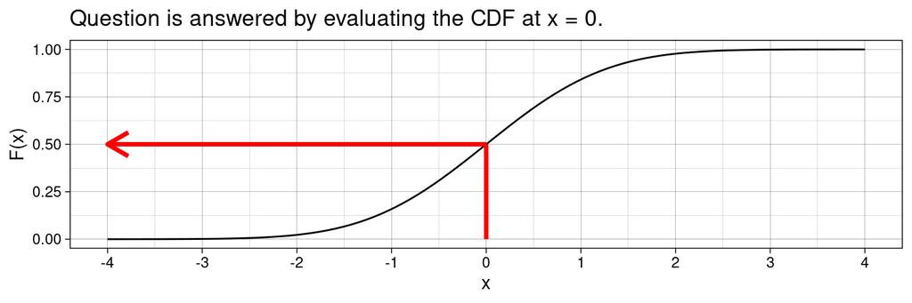

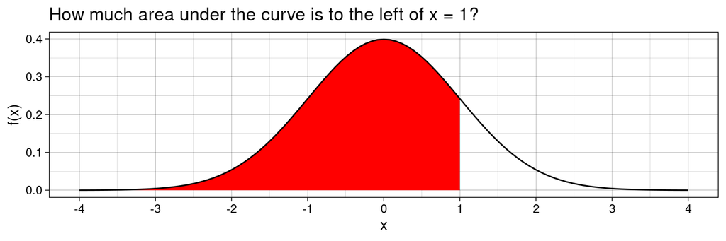

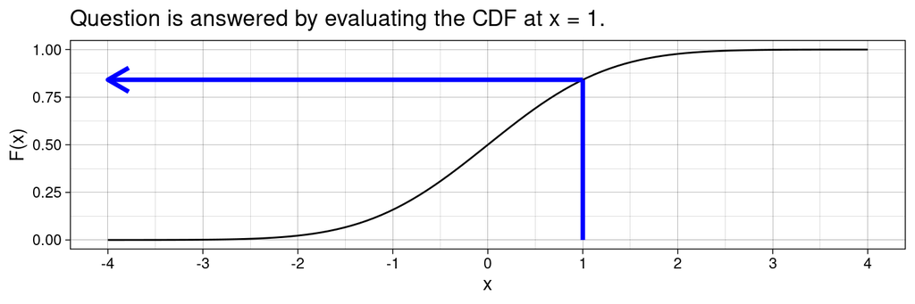

```r
ggplot() +
  stat_function(fun = pnorm, args = list(0, 1)) +
  scale_x_continuous(limits = c(-4, 4),
                     breaks = seq(from = -4, to = 4, by = 1)) +
  labs(title = "Standard Normal Distribution N(0, 1)",
       x = "x",
       y = "F(x)") +
  theme_linedraw()
```

```r
pnorm(q = 0, mean = 0, sd = 1) #lower.tail = TRUE is the default
```

```
[1] 0.5
```

```r
pnorm(q = 0, mean = 0, sd = 1, lower.tail = FALSE) #area above 0
```

```
[1] 0.5
```

```r
pnorm(q = 1, mean = 0, sd = 1) #lower.tail = TRUE is the default
```

```
[1] 0.8413447
```

```r
pnorm(q = 1, mean = 0, sd = 1, lower.tail = FALSE) # area above 1
```

```
[1] 0.1586553
```

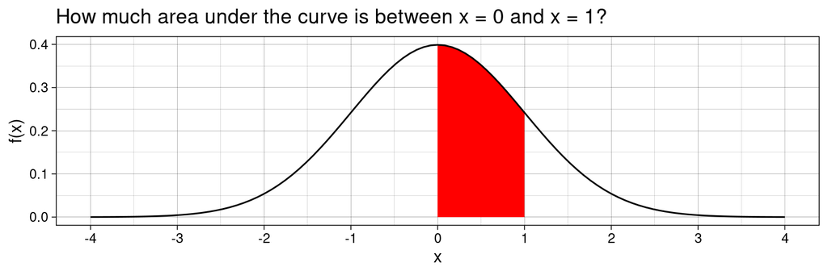

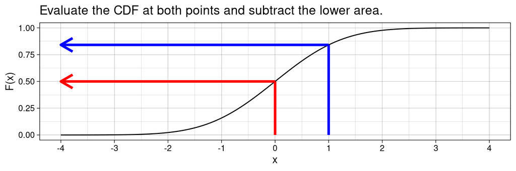

\[F(x)=P(X \leq x) = \int\limits_{0}^{1} \frac{1}{\sqrt{2\pi}\sigma}e^{-(x-\mu)^2/(2\sigma^2)}dx\]

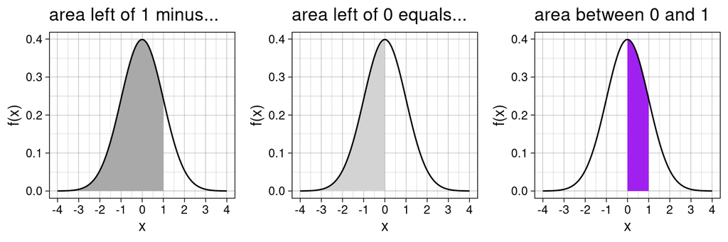

```r
pnorm(q = 1, mean = 0, sd = 1) - pnorm(q = 0, mean = 0, sd = 1)
```

```
[1] 0.3413447
```

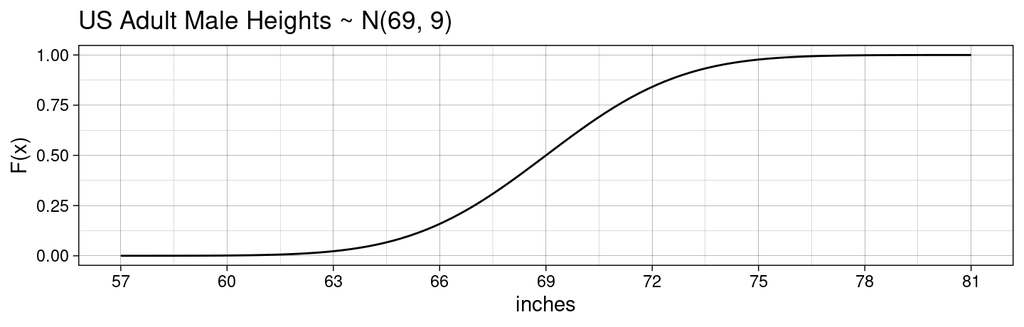

```r
mu    <- 69
sigma <- 3
ggplot() +
  stat_function(fun = pnorm, args = list(mu, sigma)) +
  scale_x_continuous(limits = c(mu - (4 * sigma), mu + (4 * sigma)),
     breaks = seq(mu - (4 * sigma), mu + (4 * sigma), sigma)) +
  labs(title = "US Adult Male Heights ~ N(69, 9)",
       x = "inches",
       y = "F(x)") +
  theme_linedraw()
```

## The Empirical Rule

The normal distribution is unimodal and perfectly symmetric.

[figure not shown]

- approximately 68% of the curve area is between \(\mu \pm 1\sigma\)
- approximately 95% of the curve area is between \(\mu \pm 2\sigma\)
- approximately 99.7% of the curve area is between \(\mu \pm 3\sigma\)

## Practice #2

1. Use `pnorm()` and \(N(0,1)\) to calculate how much area is to the *left* of the points \(\mu - 3\sigma\), \(\mu - 2\sigma\), \(\mu - 1\sigma\), \(\mu\), \(\mu + 1\sigma\), \(\mu + 2\sigma\), and \(\mu + 3\sigma\)
2. Use `pnorm()` and \(N(0,1)\) to calculate how much area is to the *right* of the points \(\mu - 3\sigma\), \(\mu - 2\sigma\), \(\mu - 1\sigma\), \(\mu\), \(\mu + 1\sigma\), \(\mu + 2\sigma\), and \(\mu + 3\sigma\)
3. The Empirical Rule tells us the approximate areas under the curve between \(\mu \pm 1\sigma\), \(\mu \pm 2\sigma\), and \(\mu \pm 3\sigma\). Use `pnorm()` and \(N(0,1)\) to calculate the exact area in these regions.
4. Verify that the areas between \(\mu \pm 1\sigma\), \(\mu \pm 2\sigma\), and \(\mu \pm 3\sigma\) are the same for the distribution of WAIS scores as they are for \(N(0,1)\) using `pnorm()`.

What percentage of the population falls into each WAIS class?

| Score Range | WAIS Class |
| --- | --- |
| 129.5 and above | Very Superior |
| 119.5 to 129.5 | Superior |
| 108.5 to 119.5 | High Average |
| 89.5 to 108.5 | Average |
| 79.5 to 89.5 | Low Average |
| 69.5 to 79.5 | Borderline |
| 69.5 and below | Extremely Low |

## Exploration #3: Quantiles

## Inverse CDF

In the discussions above, we found the area to the left of a given point (or *quantile*) on the x-axis. Sometimes we need to solve the reverse kind of problem: given an area or probability, what is the corresponding quantile or quantiles?

\(F^{-1}(x)\) = `qnorm(p, mean, sd, lower.tail = TRUE)`

If the area is to the right of the unknown value x (the upper tail) rather than to the left (the lower tail), specify upper tail.

\(F^{-1}(x)\) = `qnorm(p, mean, sd, lower.tail = FALSE)`

If we know \(\mu\), \(\sigma\), and either the value(s) of x or the area(s)…

`pnorm(q, mean, sd) = p` \(\Longleftrightarrow\) `qnorm(p, mean, sd) = q`

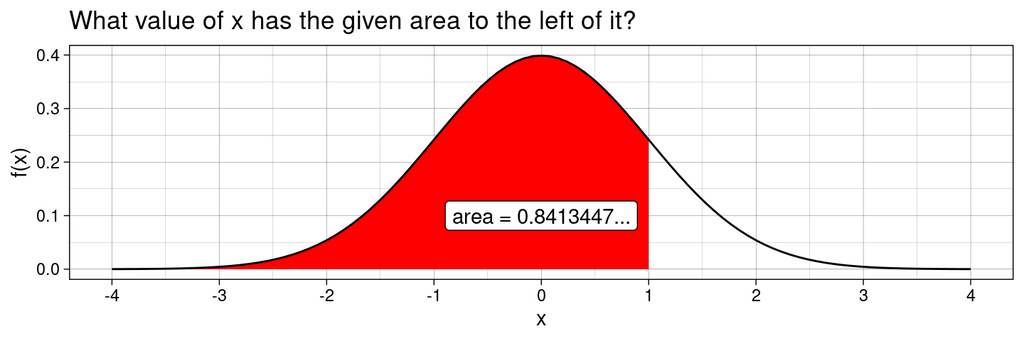

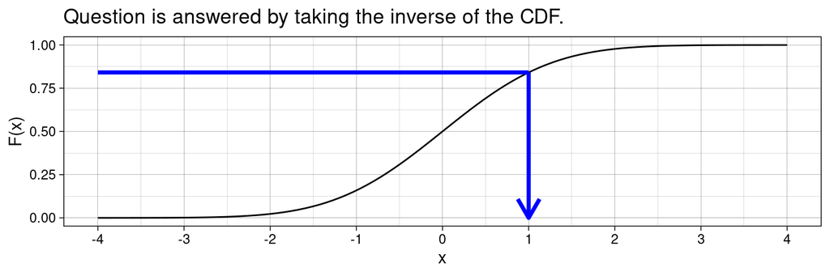

## Exploration #4: Sampling and Simulating

## Sampling from a Normal Distribution

In addition to calculating probabilities, we can simulate random normal values in `R` using `rnorm (n, mean, sd)`.

*n* = the number of random values (sample size)

*mean* = the mean of the distribution

*sd* = the standard deviation of the distribution

As with the other *norm* functions, the default parameter settings in `rnorm()` are `mean = 0` and `sd = 1`. If we want a sample from the standard normal distribution, we only need to enter a value for sample size, `rnorm(n)`.

```r
rnorm(5)
```

```
[1]  0.4211795 -0.2075471 -1.4276854  1.0756172 -0.4114465
```

```r
rnorm(10)
```

```
 [1]  0.4785806  0.9431710  0.7546148 -1.9583217 -0.1274710  0.5429227
 [7]  0.6142890 -0.8888029 -1.2465032 -1.5030277
```

```r
rnorm(25)
```

```
 [1] -0.56871924 -0.19266601 -1.09582369  1.26106061 -0.51513563  1.16643802
 [7]  1.54575830  0.75349978 -2.03370805  0.58981775  0.85674924  0.98586466
[13]  1.01208970 -1.11623753 -1.14954466  1.04427854  0.68334674 -0.27687876
[19]  1.71964293 -0.43343556 -0.28060567 -0.54324640  1.16422883  0.21279963
[25] -0.05012587
```

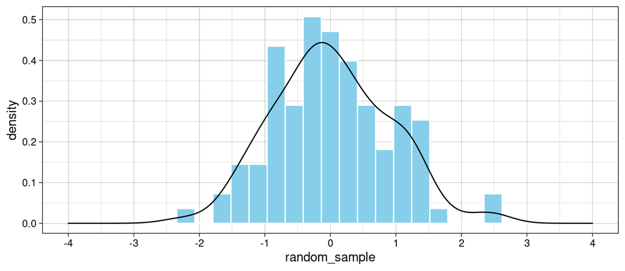

```r
random_sample <- rnorm(100)
ggplot(NULL, aes(x = random_sample)) +
  geom_histogram(aes(y = ..density..), bins = 30,
                 fill = "skyblue", color = "white") +
  geom_density() +
  scale_x_continuous(limits = c(-4, 4), breaks = seq(from = -4, to = 4, by = 1)) +
  theme_linedraw()
```

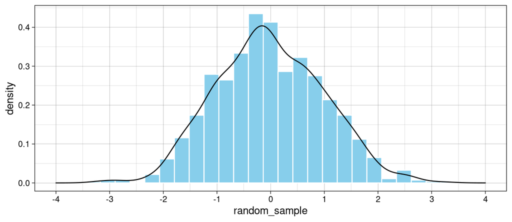

```r
random_sample <- rnorm(1000)
ggplot(NULL, aes(x = random_sample)) +
  geom_histogram(aes(y = ..density..), bins = 30,
                 fill = "skyblue", color = "white") +
  geom_density() +
  scale_x_continuous(limits = c(-4, 4), breaks = seq(from = -4, to = 4, by = 1)) +
  theme_linedraw()
```

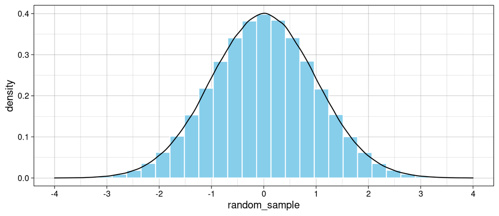

```r
random_sample <- rnorm(10^6)
ggplot(NULL, aes(x = random_sample)) +
  geom_histogram(aes(y = ..density..), bins = 30,
                 fill = "skyblue", color = "white") +
  geom_density() +
  scale_x_continuous(limits = c(-4, 4), breaks = seq(from = -4, to = 4, by = 1)) +
  theme_linedraw()
```

## Practice #4: Simulating Data

1. Generate samples of different sizes from a standard normal distribution.
2. Generate samples of different sizes from the various IQ tests we discussed.
3. Use your EDA skills to explore and plot the various samples. Do the distributions look bell-shaped? Do they have close to what you would expected for mean and standard deviation? Are there any outliers?
4. How does sample size impact your results? Where do you see more variability from sample to sample?

## JB Statistics Videos

## Intro to the Normal Distribution

[video not shown]

## Standardizing Normal Variables

[video not shown]